# Differential RNA-seq of Vibrio cholerae identifies the small RNA as a regulator of biofilm formation

## Methods: tRAX - tRNA Analysis of eXpression

To perform gene expression analysis, we used the software tRAX. tRAX is a multi-stage pipeline that is developed for in-depth analyses of tRNA-derived small RNAs (tDRs), mature tRNAs. tRAX uses python to develop the main functionality for the framework and R language for visualization. For this study purpose, tRAX docker container was used.

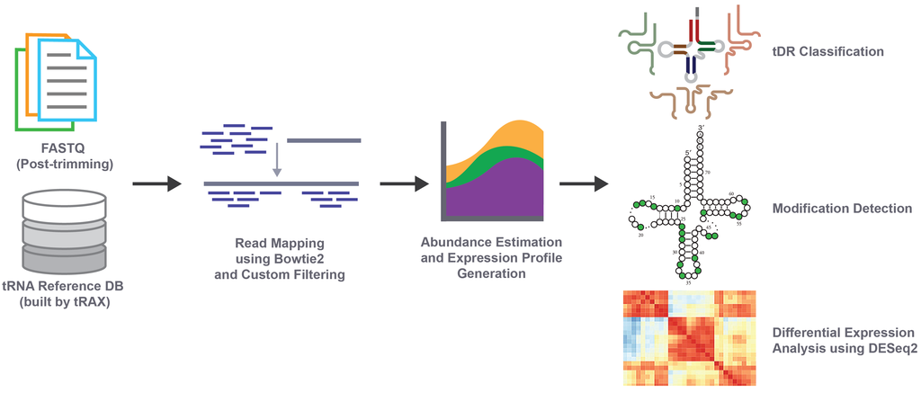

tRAX software Multistage pipeline used for differential expression analysis

#### Creating reference database

As the first step for performing gene expression analysis using tRAX, a reference database is constructed by integrating the input reference genome and tRNAScan-SE annotation of the v. cholerae strain N16961. Its purpose is to ensure accurate alignment of sequencing reads, tailored specifically for tRNA and tDR analysis. Within the tRAX toolkit, a tool named maketrnadb.py facilitates researchers in generating this database. By amalgamating annotations from tRNAscan-SE and sequences sourced from the Genomic tRNA database(GtRNAdb) with the organism's genome sequence, this tool crafts a Bowtie2 read mapping index. This comprehensive index encompasses both the unique set of mature tRNAs and the genome sequence, vital for subsequent analysis.

$ maketrnadb.py --databasename=pratik --genomefile=data/ref_genome.fna --trnascanfile=data/vibrChol1-tRNAs.out --namemapfile=data/vibrChol1-tRNAs_name_map.txt --orgmode='bact'

#### Adapter Trimming for single-end reads

The preprocessing step of the input sequence reads before performing gene expression analysis is a critical task: eliminating adapters utilized during sequencing library preparations from the raw sequencing reads. tRAX, an integral toolkit for such analyses, incorporates a specific adapter trimming tool known as trimadpaters.py, designed for this precise purpose.

In the dataset utilized for this study, featuring single-end reads, tRAX strategically employs the cutadapt [6] tool to target and remove adapter sequences typically associated with small RNA sequencing methodologies. The default adapter sequences for removal, namely “AGATCGGAAGAGCACACGTC” and “GATCGTCGGACTGTAGAACTC,” are commonly integrated into small RNA-seq library preparation kits compatible with the Illumina sequencing platform.

Post adapter trimming, a comprehensive quality assessment report includes a summary of the statistical. These statistics serve as a valuable resource, offering insights into the efficacy of the adapter removal process. Subsequently, the set of sequencing reads retained after this meticulous trimming procedure stands poised for utilization in the subsequent step of the process, specifically for read mapping, as further elucidated in the subsequent sections.

$ trimadapters.py --runname pratik_run --runfile exp_data/runfile.txt --singleend

#### Aligning sequencing and Gene Expression Analysis.

The final and pivotal phase of expression analysis using tRAX involves aligning the input sequences with reference databases constructed using Bowtie and executing gene expression analysis. For this step, sequence reads without adapters as inputs are used into the primary tRAX tool, processesamples.py. This comprehensive tool encompasses crucial functions like read mapping, abundance estimation, and differential expression analysis.

Sequencing reads undergo alignment with the created reference database employing Bowtie2. tRAX computes raw read counts and compiles them into a tab-delimited file, a crucial step for normalization and subsequent differential expression analysis. Importantly, this computation encompasses read counts not only for tRNAs but also for other small RNA genes. To facilitate this process, gene annotations need specification within the Ensembl GTF file format, including the classification of gene types [3]. tRAX further furnishes summary statistics detailing the alignment distribution of total read counts specific to each gene type within the provided samples. The output from tRAX includes text files and histograms that illustrate the distribution of read counts associated with each gene type and tRNA isotype in every sample. Additionally, this tool calculates and presents the distribution of read lengths, comparing tRNAs against other gene types, depicted in corresponding text files and charts for comprehensive visualization and comparison purposes.

In the initial stage, raw read counts of tRNAs, tDRs, and other small RNAs are combined and fed into DESeq2 [7] to compute normalization size factors per sample, facilitating the calculation of normalized read counts for inter-sample comparison within tRAX. Simultaneously, tRAX integrates metadata concerning experimental design, encompassing replicate groups, conditions, and sample pairings for subsequent expression comparisons. This study specifically undertook two distinct expression comparisons: firstly, between stationary and biofilm conditions, and secondly, between exponential and biofilm conditions. Employing DESeq within the pipeline, log2 fold changes and adjusted P-values were computed for each specified sample pair, resulting in an output file containing tab-delimited data, including normalized read counts, log2 fold changes, and adjusted P-values, offering valuable insights into comparative expression patterns.

$ processsamples.py --experimentname=pratik_exp --databasename=pratik --ensemblgtf=data/GCF_000006745.1_ASM674v1_genomic.gtf --samplefile=exp_data/samplefile.txt --exppairs=exp_data/samplepair.txt